# Atmospheric concentration studies of co2

Time series-Coursework 1

Haiqing Song

March 2024

## Co2 short-term forecasts and cyclical changes

The project analysed time series of CO2 data, predicted future trends using Meta’s Prophet forecasting tool, and explored cyclical patterns in CO2 concentrations over time, focusing on seasonal, daily and weekly variations. Firstly, `install.packages("remotes)` `remotes::install_github('facebook/prophet@*release',subdir='R')`

co2 is a data frame containing the atmospheric concentration of carbon dioxide and is a time series of 468 observations; observations are made monthly from 1959 to 1997.

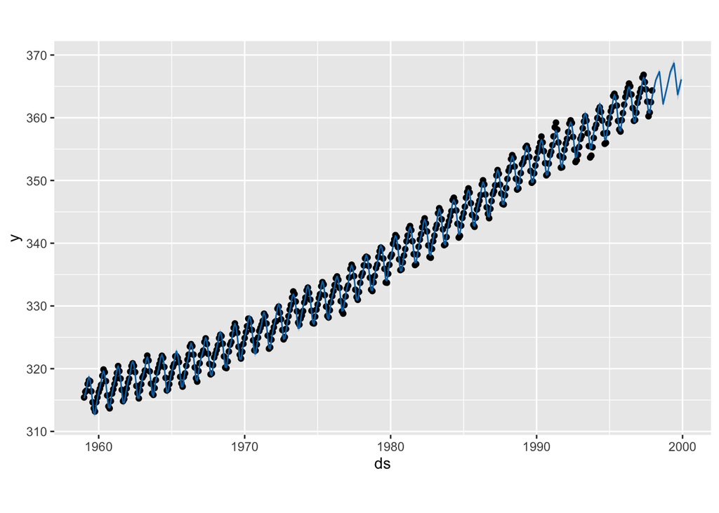

```r
co2.df = data.frame(
  ds=zoo::as.yearmon(time(co2)),
  y=co2)
m = prophet::prophet(co2.df,weekly.seasonality = TRUE,daily.seasonality = TRUE)
f = prophet::make_future_dataframe(m, periods=8, freq="quarter")
p = predict(m, f)
plot(m,p)
```

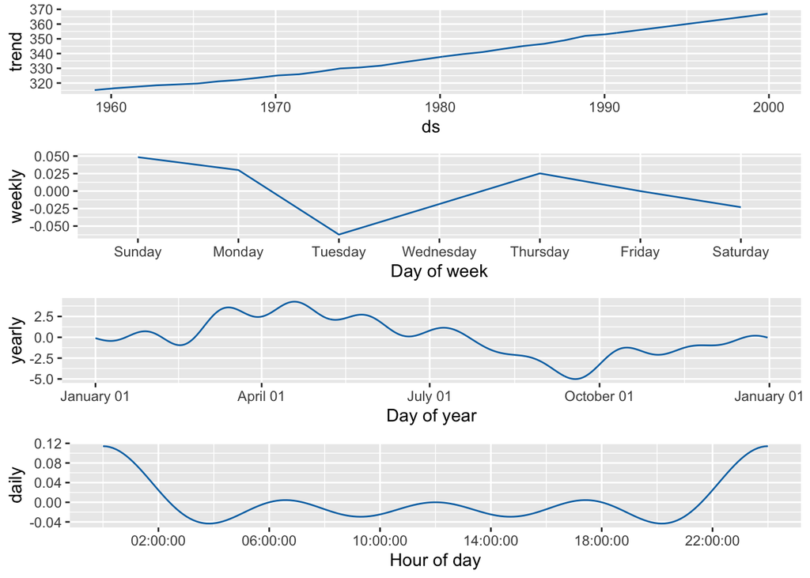

```r
prophet::prophet_plot_components(m,p)
```

```r
prophet::dyplot.prophet(m,p)
```

[interactive chart not shown]

The dyplot provides a detailed view of each data point.

## Long-term forecasts and uncertainty intervals

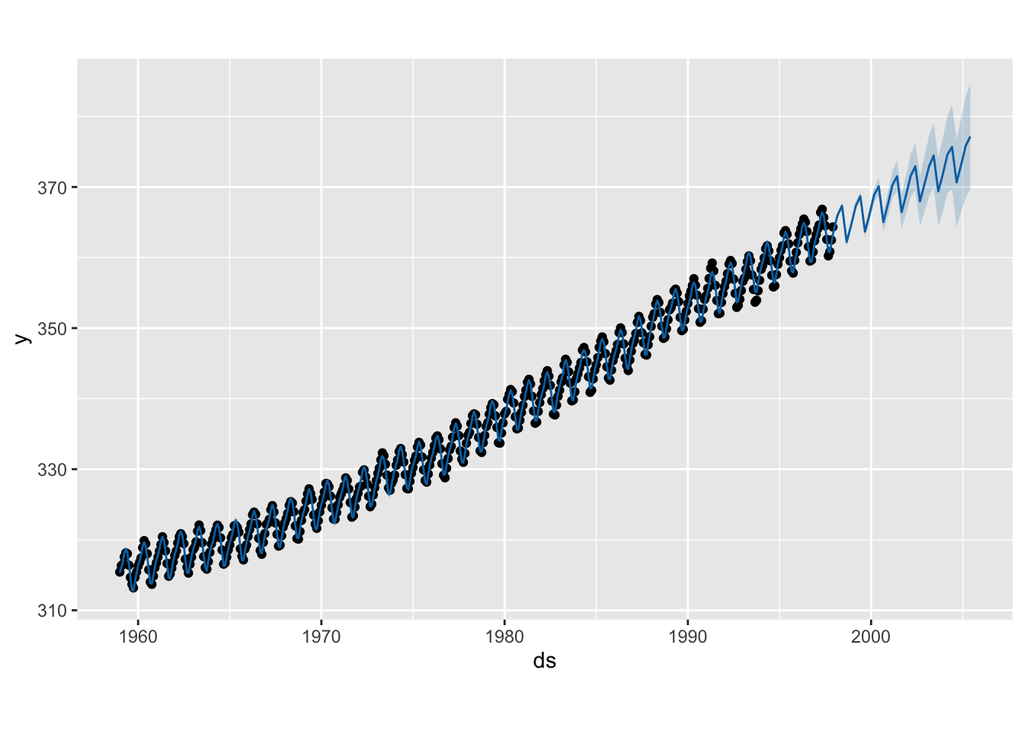

```r
future2 = prophet::make_future_dataframe(m, periods=30, freq="quarter")
predict2= predict(m, future2)
plot(m,predict2)
```

### Visualisation of uncertainty

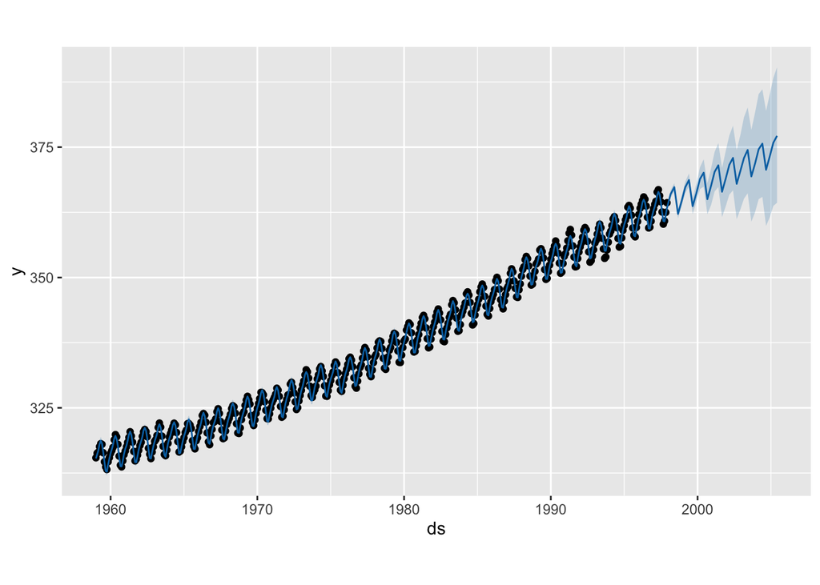

```r
m1= prophet::prophet(co2.df,weekly.seasonality = TRUE,daily.seasonality = TRUE,interval.width = 0.95)
future3 = prophet::make_future_dataframe(m1, periods=30, freq="quarter")
predict3= predict(m1, future2)
plot(m1,predict3)
```

By increasing the confidence interval, we can observe that the uncertainty in the future prediction of CO2 concentration becomes larger, suggesting that there is a large range of potential fluctuations in co2 concentration in the long-term prediction.